# Multi-cytokine HRECs Markdown

Fergus McLellan

2024-11-14

# Introduction

To begin, I load tidyverse and run some code to clear my environment and set my desired information printing parameters

```r
#rm(list = ls(all.names = TRUE)) unhash to clear environment
#gc() unhash to clear cache
options(max.print = .Machine$integer.max, scipen = 999, stringsAsFactors = F, dplyr.summarise.inform = F) #sets integer limit to max

library(tidyverse) #contains multiple packages for general tidiness
library(magrittr) #package adding useful functions for pipe operator
library(dtplyr) #package adding useful functions for pipe operator
library(textshaping)

set.seed(12345)
```

next, I set my and input/output paths

```r
in_path <- "raw_data/" #set input path from working directory
out_path = "significant_data/" # set output path from working directory
```

# Differential Expression Analysis

The following section will describe the steps undertaken for initial differential expression analysis, with the goal of producing: 1. Normalized counts 2. Principal component analysis 3. Significantly differentially expressed gene lists

This markdown will use analysis in Part 2 as an example, however the same techniques were applied for Part 1 with names swapped to match experimental groups used (Control DMFu VEGF VEGFDMFu).

This data was then exported as .CSV files and used in [**morpheus**](https://software.broadinstitute.org/morpheus/) **to generate count heatmaps** (*Figure 1B*) and [**biovenn**](https://www.biovenn.nl/index.php) **for venn diagram generation**.

## DESeq2

Differential expression analysis using DESEQ2

There are 3 objects required for DESeq to run properly:

1. A *Counts* matrix, with one 1 set of labels (Ensembl ID in this case) as the row name
2. A *Design* factor with 1 level per treatment, and repetitions = n
3. A *colData* data frame containing a column reflecting the design

### Data and meta data

#### Counts matrix

```r
Counts <-read.delim(paste0(in_path,"raw_counts.csv"), header = TRUE, row.names = 1, sep = ",")

Counts <- as.matrix(Counts[,1:48])

head(Counts)
```

```
##                 Control_1 Control_2 Control_3 Control_4 Control_5 Control_6
## ENSG00000223972         0         0         0         0         0         0
## ENSG00000227232       100        90       110        99       134       112
## ENSG00000278267        18        12        16        22        24        10
## ENSG00000243485         0         0         0         0         0         0
## ENSG00000237613         0         0         0         0         0         0
## ENSG00000268020         0         0         0         0         0         0
##                 TGFb1_1 TGFb1_2 TGFb1_3 TGFb1_4 TGFb1_5 TGFb1_6 TGFb2_1 TGFb2_2
## ENSG00000223972       0       0       0       0       0       0       0       0
## ENSG00000227232      76     110     137      92     136      92      88     108
## ENSG00000278267      26      19      27      30      12      22      16      18
## ENSG00000243485       0       0       0       0       0       0       0       0
## ENSG00000237613       0       0       0       0       0       0       0       0
## ENSG00000268020       0       0       0       0       0       0       0       0
##                 TGFb2_3 TGFb2_4 TGFb2_5 TGFb2_6 TNFa_1 TNFa_2 TNFa_3 TNFa_4
## ENSG00000223972       0       0       0       0      0      0      0      0
## ENSG00000227232      92     126     128     102     97     85    135    103
## ENSG00000278267      14      21      35      13     14     14     22     13
## ENSG00000243485       0       0       0       0      0      0      0      0
## ENSG00000237613       0       0       0       0      0      0      0      0
## ENSG00000268020       0       0       0       0      0      0      0      0
##                 TNFa_5 TNFa_6 Thrombin_1 Thrombin_2 Thrombin_3 Thrombin_4
## ENSG00000223972      0      0          0          0          0          0
## ENSG00000227232    106    115        106        116         89         60
## ENSG00000278267     13     11         12         18         24         19
## ENSG00000243485      0      0          0          0          0          0
## ENSG00000237613      0      0          0          0          0          0
## ENSG00000268020      0      0          0          0          0          0
##                 Thrombin_5 Thrombin_6 IL.6_1 IL.6_2 IL.6_3 IL.6_4 IL.6_5 IL.6_6
## ENSG00000223972          0          1      0      0      0      0      0      0
## ENSG00000227232         93         93     68    127    105     72    107     80
## ENSG00000278267         14         14     16     24      9     22     17     21
## ENSG00000243485          0          0      0      0      0      0      0      0
## ENSG00000237613          0          0      0      0      0      0      0      0
## ENSG00000268020          0          0      0      0      0      0      0      0
##                 VEGF_1 VEGF_2 VEGF_3 VEGF_4 VEGF_5 VEGF_6 All_1 All_2 All_3
## ENSG00000223972      0      0      0      0      1      0     0     0     0
## ENSG00000227232    103     70     75     89    100    108    98    80   113
## ENSG00000278267      5     15     21     22     15     11    21    23    11
## ENSG00000243485      0      0      0      0      0      0     0     0     0
## ENSG00000237613      0      0      0      0      0      0     0     0     0
## ENSG00000268020      0      0      0      0      0      0     0     0     0
##                 All_4 All_5 All_6
## ENSG00000223972     0     0     0
## ENSG00000227232   112    72    91
## ENSG00000278267    24    16    23
## ENSG00000243485     0     0     0
## ENSG00000237613     0     0     0
## ENSG00000268020     0     0     0
```

#### Meta Data

So as to keep the global environment neat, a custom function was written to generate meta data based on the investigation being performed.

```r
#Possible comparison types: all_groups, fibro, inflam, angio, single *IF SINGLE MUST ALSO IDENTIFY TREATMENT*
metadatapicker <- function(comparisontype, treatment = NULL){



  if(comparisontype == "important"){
    condition <- factor(c(rep("Control", 6), rep("TGFb2", 6), rep("TNFa", 6), rep("Thrombin", 6), rep("ALL", 6)))
    coldata <- data.frame(condition)
    coldata$condition <- relevel(coldata$condition, ref = "Control")

    # All Condition ---------------------------------------------------------

  }else if (comparisontype == "all"){

    condition <- factor(c(rep("Control", 6), rep("TGFb1", 6), rep("TGFb2", 6), rep("TNFa", 6), rep("Thrombin", 6) , rep("IL6", 6), rep("VEGF", 6), rep("ALL", 6)))
    coldata <- data.frame(condition)
    coldata$condition <- relevel(coldata$condition, ref = "Control")

    # Fibro Condition ---------------------------------------------------------

  }else if (comparisontype == "fibro"){

    condition <- factor(c(rep("Control", 6), rep("TGFb1", 6), rep("TGFb2", 6), rep("TNFa", 6), rep("Thrombin", 6)))
    coldata <- data.frame(condition)
    coldata$condition <- relevel(coldata$condition, ref = "Control")

    # Inflam Condition --------------------------------------------------------

  }else if (comparisontype == "inflam"){

    condition <- factor(c(rep("Control", 6), rep("TGFb1", 6), rep("TNFa", 6), rep("Thrombin", 6) , rep("IL6", 6)))
    coldata <- data.frame(condition)
    coldata$condition <- relevel(coldata$condition, ref = "Control")

    # Angio Condition ---------------------------------------------------------

  }else if (comparisontype == "angio"){

    condition <- factor(c(rep("Control", 6), rep("TGFb2", 6), rep("Thrombin", 6) ,rep("VEGF", 6)))
    coldata <- data.frame(condition)
    coldata$condition <- relevel(coldata$condition, ref = "Control")

    # Individuals only (no cocktail) ---------------------------------------------------------

  }else if (comparisontype == "individuals"){
    condition <- factor(c(rep("Control", 6), rep("TGFb1", 6), rep("TGFb2", 6), rep("TNFa", 6), rep("Thrombin", 6) , rep("IL6", 6), rep("VEGF", 6)))
    coldata <- data.frame(condition)
    coldata$condition <- relevel(coldata$condition, ref = "Control")


    # Single Comparison Condition ---------------------------------------------

  }else if (comparisontype == "single"){

    if(!is.null(treatment)){
      condition <- factor(c(rep("Control", 6), rep(treatment, 6)))
      coldata <- data.frame(condition)
      coldata$condition <- relevel(coldata$condition, ref = "Control")

    }else{
      print("Please select a treatment for your single comparison. Returning only Control group in data frame")
    }

  }else{
    print("Invalid selection. Please choose from the list of possible comparisons.")
    return(NULL)
  }

  return(list("condition" = condition, "coldata" = coldata,"name"= paste0(comparisontype,"_",treatment)))

}
```

Use function to set meta data. Allows: - all - individuals - important - fibro - inflam - angio - single*

*single comparisons requires selection of the treatment of interest

Assign a list for the meta data objects and split this list to give a condition factor and coldata data frame object

```r
metadata <- metadatapicker(comparisontype = "all",
                         treatment =
                          ) %>%
               list2env(.GlobalEnv)
```

##### Condition Factor

```r
levels(condition)
```

```
## [1] "ALL"      "Control"  "IL6"      "TGFb1"    "TGFb2"    "Thrombin" "TNFa"
## [8] "VEGF"
```

##### colData Data frame

```r
unique(coldata)
```

```
##    condition
## 1    Control
## 7      TGFb1
## 13     TGFb2
## 19      TNFa
## 25  Thrombin
## 31       IL6
## 37      VEGF
## 43       ALL
```

### Data Cleaning

Next, it is good practice to clean the data, removing any NA values, or unusable counts. For this I have used the WGCNA package goodSamplesGenes function.

```r
library(WGCNA, quietly = TRUE) #Weighted Gene Co-expression Analysis package containing GoodSamplesGenes check

ddsCounts <- Counts #create duplicate of Counts before manipulating counts

gsg <- goodSamplesGenes(t(ddsCounts))
```

```
##  Flagging genes and samples with too many missing values...
##   ..step 1
##   ..step 2
```

```r
summary(gsg)
```

```
##             Length Class  Mode
## goodGenes   57500  -none- logical
## goodSamples    48  -none- logical
## allOK           1  -none- logical
```

```r
gsg$allOK #false in all ok indicates NA Values/iterative 0 values
```

```
## [1] FALSE
```

```r
table(gsg$goodGenes) # individual gene check (iterative check for repeated 0 values)?
```

```
##
## FALSE  TRUE
## 18955 38545
```

```r
table(gsg$goodSamples) #sample check
```

```
##
## TRUE
##   48
```

```r
ddsCounts <- ddsCounts[gsg$goodGenes == TRUE, gsg$goodSamples == TRUE] #omit bad genes
```

### Run DESeq2

DESeq2 was utilised to perform repeated wald tests to identify significantly differentially expressed genes. Several output objects were generated for future use: - DESeq object - Normalised counts data frame - Averaged normalised counts data frame - Variance stabilised counts data frame

```r
dds <- DESeqDataSetFromMatrix(countData = ddsCounts, colData = coldata, design= ~condition)

dds <- DESeq(dds)
res <- results(dds) #results object example
```

```
## [1] "38545 genes examined, example results object:"
```

```
## log2 fold change (MLE): condition VEGF vs Control
## Wald test p-value: condition VEGF vs Control
## DataFrame with 6 rows and 6 columns
##                   baseMean log2FoldChange     lfcSE       stat     pvalue
##                  <numeric>      <numeric> <numeric>  <numeric>  <numeric>
## ENSG00000223972  0.0444196       0.370065  5.889216  0.0628377 0.94989571
## ENSG00000227232 98.8416405      -0.355984  0.122943 -2.8955075 0.00378546
## ENSG00000278267 17.8343074      -0.282354  0.294598 -0.9584400 0.33784093
## ENSG00000238009  0.1769574      -1.072555  3.354243 -0.3197608 0.74914968
## ENSG00000233750  0.5498715      -0.651585  1.742873 -0.3738567 0.70851090
## ENSG00000268903  4.8581692      -0.266914  0.498427 -0.5355127 0.59229540
##                      padj
##                 <numeric>
## ENSG00000223972        NA
## ENSG00000227232 0.0283983
## ENSG00000278267 0.6009277
## ENSG00000238009        NA
## ENSG00000233750        NA
## ENSG00000268903        NA
```

Normalised counts can be exported as .csv for use in web tools, or as an RDS using:

```r
#saveRDS(dds, file= paste0(in_path,name,"dds.RDS"))  #unhash to save RDS
```

Generating an average, normalised counts data frame and variance stabilised transformation data frame

```r
avg_ncounts <- sapply(seq(1, ncol(normcounts), 6), function(j) rowMeans(normcounts[,j+(0:(5))])) %>% #sequences along columns and averages every 6 columns
  as.data.frame()%>% #represents the result as a data frame
  set_colnames(levels(condition)) #sets the column names to match the levels of condition


vsdata <- vst(dds, blind= FALSE) #variance stablising transformation for PCA
vscounts <- assay(vsdata) #variance stabilised counts
```

## Principal Component Analysis

### Load Necessary Packages

```r
library(RColorBrewer) #color palettes
library(ggplot2) #plotting package
library(ggrepel) #text and point repel
library(svglite) #save SVGs
```

### Plot PCA in ggplot

Generate PCA using ggplot2 **plotPCA**

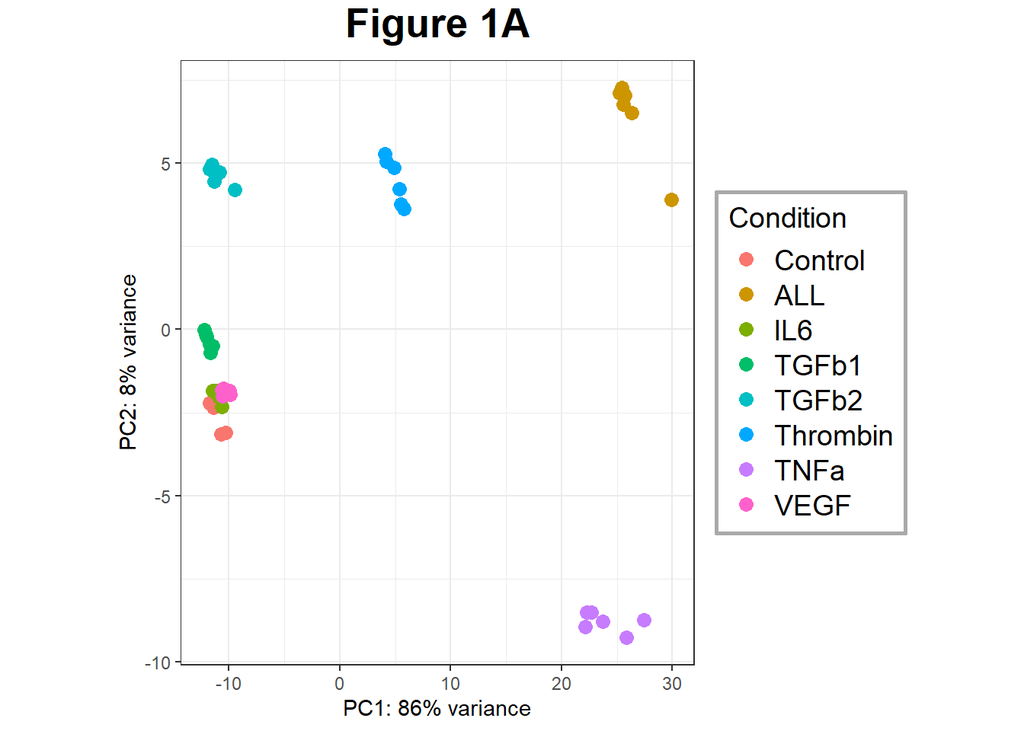

```r
PCA <- plotPCA(vsdata, intgroup = "condition", ntop = 1000)+
  theme_bw()+ #base theme
  coord_equal(3)+ #set a plot size
  labs(title = "Figure 1A", color = "Condition")+ #labels
  theme(plot.title = element_text(hjust=0.5,vjust = 1.5, size = 20, face = "bold", color = "black"),
        legend.title = element_text(size=14), legend.text = element_text(size=14),
        legend.margin = margin(0.2, 0.2, 0.2, 0.2, "cm"),
        legend.spacing = unit(2, "cm"),
        legend.key.size = unit(1.2, "lines"),
        legend.background = element_rect(fill = ,linewidth = 1, linetype ="solid", colour = "darkgrey"))
```

Further style changes were made in an external vector editor to increase legibility for **Figure 1A**, these include: - Adding of ellipses bounding points - Adjustments to color scheme - Removal of cocktail group

### Numerical PCA

Kruskal test is only really exploratory, and is best applied when performing a single comparison to assess significance of difference between groups.

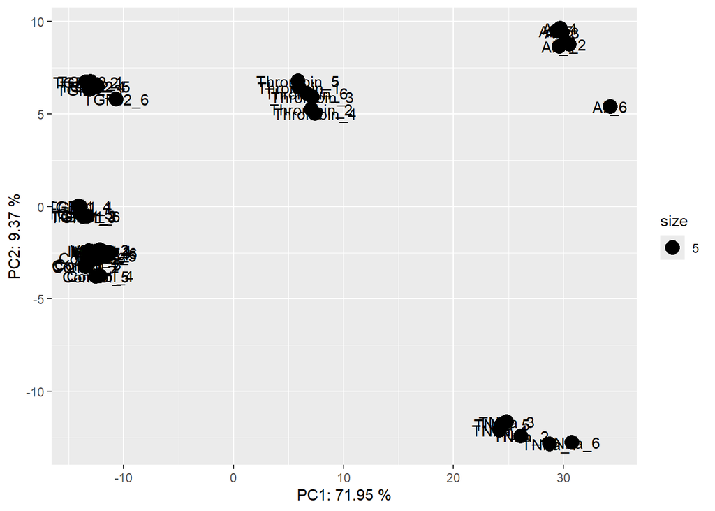

```r
pca <- prcomp(t(vscounts))
pca.dat <- pca$x

pca.var <- pca$sdev^2 #variance as standard deviation squared

pca.var.percent <- round(pca.var/sum(pca.var)*100, digits = 2) #percentage of explained variance

pca.dat <- as.data.frame(pca.dat) #convert to dataframe so its usable

ggplot(pca.dat, aes(PC1, PC2)) + #check that the PCA being assessed is similar to PCAplot
  geom_point(aes(size = 5)) +
  geom_text(label = rownames(pca.dat)) +
  labs(x = paste0('PC1: ', pca.var.percent[1], ' %'),
       y = paste0('PC2: ', pca.var.percent[2], ' %'),
  )
```

```r
P1 <- kruskal.test(pca.dat$PC1 ~ condition)
```

```
##
##  Kruskal-Wallis rank sum test
##
## data:  pca.dat$PC1 by condition
## Kruskal-Wallis chi-squared = 43.111, df = 7, p-value = 0.0000003176
```

```r
P2 <- kruskal.test(pca.dat$PC2 ~ condition)
```

```
##
##  Kruskal-Wallis rank sum test
##
## data:  pca.dat$PC2 by condition
## Kruskal-Wallis chi-squared = 44.451, df = 7, p-value = 0.0000001748
```

## Significance Check

Custom, loopable function to export a .csv of DESeq2 log<sub>2</sub> Fold Change, with additional introduced columns: - HGNC gene symbols - ENTREZ gene IDs - Differential expression status (UP, Down or NO) referencing adjustable limits

```r
library(org.Hs.eg.db) #read in annotation DBI human database


significance <- function(condition, treatment, Padj = 0.05, L2FC = 0, version){

  library(DESeq2)

  res <- results(dds, contrast = c(condition,treatment, "Control"), )

  sigdeg_df<- as.data.frame(res) #generate results data frame

  sigdeg_df$symbol<- mapIds(org.Hs.eg.db,
                            keys = rownames(sigdeg_df),
                            keytype = "ENSEMBL", column = "SYMBOL") #gene symbols
  sigdeg_df$ENTREZID<- mapIds(org.Hs.eg.db,
                              keys = rownames(sigdeg_df),
                              keytype = "ENSEMBL", column = "ENTREZID") #ENTREZ IDs

  sigdeg_df <- sigdeg_df %>%
    mutate(diffexpressed = case_when(
      log2FoldChange > +(L2FC) & padj < Padj ~ 'UP', #check if up regulated
      log2FoldChange < -(L2FC) & padj < Padj ~ 'DOWN', #check if down regulated
      padj > Padj ~ 'NO', #check if not significant
      TRUE ~ 'NO' #Label anything else as this (good for troubleshooting)
    ))
  sigdeg_df <- sigdeg_df[sigdeg_df$diffexpressed != "NO",]


  write.csv(sigdeg_df, file = paste0(out_path,treatment,"_deg_table_",version,".csv"))

  print(paste0(treatment," DEG Table with L2FC cut-off = ",L2FC," and adjusted p=value cut-off = ",Padj," generated in ",out_path,"."))

  }
```

When running the function, ensure a condition has been established using *metadatapicker*

```r
#significance(condition = "condition",
            #treatment = "ALL",
             #L2FC = 1,
             #Padj = 0.05,
            #version = "0L2FC_cutoff_003")


cytokines <- c("TGFb1","TGFb2","TNFa","Thrombin","IL6","VEGF","ALL")

for (cytokine in cytokines) {
  significance(condition = "condition",
               treatment = cytokine,
               L2FC = 1,
               Padj = 0.05,
               version = "1L2FC_nobaseMean_cutoff_004")
  }
```

```
## [1] "TGFb1 DEG Table with L2FC cut-off = 1 and adjusted p=value cut-off = 0.05 generated in significant_data/."
```

```
## [1] "TGFb2 DEG Table with L2FC cut-off = 1 and adjusted p=value cut-off = 0.05 generated in significant_data/."
```

```
## [1] "TNFa DEG Table with L2FC cut-off = 1 and adjusted p=value cut-off = 0.05 generated in significant_data/."
```

```
## [1] "Thrombin DEG Table with L2FC cut-off = 1 and adjusted p=value cut-off = 0.05 generated in significant_data/."
```

```
## [1] "IL6 DEG Table with L2FC cut-off = 1 and adjusted p=value cut-off = 0.05 generated in significant_data/."
```

```
## [1] "VEGF DEG Table with L2FC cut-off = 1 and adjusted p=value cut-off = 0.05 generated in significant_data/."
```

```
## [1] "ALL DEG Table with L2FC cut-off = 1 and adjusted p=value cut-off = 0.05 generated in significant_data/."
```

## Volcano Plots

Here, I utilise *enhancedVolcano* to generate a volcano plot, with the top 10 highest log<sub>2</sub> Fold Change DEGs labelled.

This code will function irrespective of if above **Significance Check** has been run.

First, read in results object for comparison to be plotted

```r
library(EnhancedVolcano)
cytokine = "TGFb2"
version = "001"

#volcanomaker <- function(cytokine,version){
  set.seed(12345)

  res <- results(dds, contrast = c("condition", cytokine, "Control"))
  sigdeg <- na.omit(res)

  sigdeg_df<- as.data.frame(sigdeg)
```

Next, label with HGNC symbols, and assign Up, Down and NS labels with colors associated based on volcano plot parameters. This is not required in enhancedVolcano as the package will identify and label based on *Pcutoff* and *Fcutoff* values, however allows for the custom colour filtering used later.

```r
#Labelling system
  sigdeg_df$symbol<- mapIds(org.Hs.eg.db,
                            keys = rownames(sigdeg_df),
                            keytype = "ENSEMBL",
                            column = "SYMBOL")

  sigdeg_df <- sigdeg_df %>%
    mutate(diffexpressed = case_when(
      log2FoldChange > 1 & padj < 0.05 ~ "UP",
      log2FoldChange < -1 & padj < 0.05 ~ "DOWN",
      between(sigdeg_df$log2FoldChange, -1, 1) ~ "NO",
      padj > 0.05 ~ 'NO',
  ))

  sigdeg_df$padj <- ifelse(sigdeg_df$padj == 0, .Machine$double.xmin, sigdeg_df$padj) #ifelse to replace 0 values in padj with machine minimum

keyvals <- ifelse(sigdeg_df$diffexpressed == "DOWN", 'royalblue',
                  ifelse(sigdeg_df$diffexpressed == "UP", 'red2','grey'))

names(keyvals)[keyvals == 'royalblue'] <- 'Down-Regulated'
names(keyvals)[keyvals == 'red2'] <- 'Up-Regulated'
names(keyvals)[keyvals == "grey"] <- 'NS'
```

Select a certain number of DEGs to be labelled, this section of code can be lengthened to slice separately for up and down-regulated genes by pulling separate slices based on *sigdeg_df$diffexpressed* value. Here, the top 10 overall were selected.

```r
selected <- sigdeg_df %>%
  arrange(desc(abs(log2FoldChange))) %>%
  filter(diffexpressed != 'NO')%>%
  filter(!is.na(symbol))%>%
  dplyr::slice(1:10)
```

Generate volcano plot with no labels

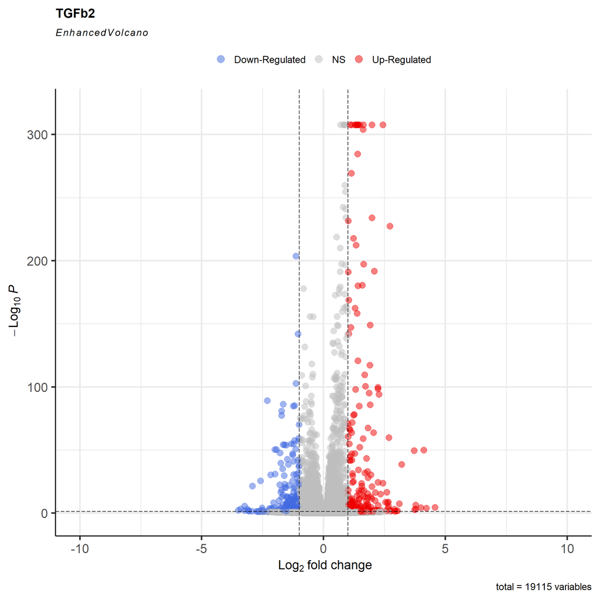

Append down-regulated labels

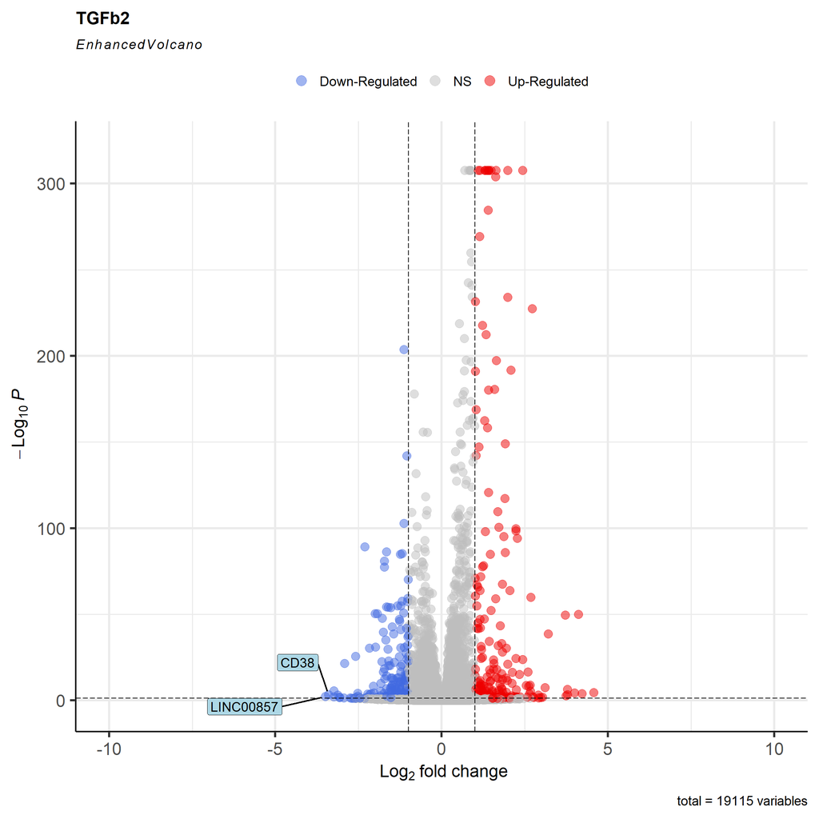

```r
# Add labels using geom_text_repel
volc2 <- volc + geom_label_repel(data = sigdeg_df[sigdeg_df$log2FoldChange < -1 & sigdeg_df$padj <0.05 & sigdeg_df$symbol %in% selected$symbol, ], #labels negative DEGs in 'selected'
                                 aes(x = log2FoldChange, y = -log10(padj), label = symbol),
                                 size = 5,
                                 label.size = 0.1,
                                 box.padding = 1.0,  # Increase box padding
                                 point.padding = 0.5,  # Increase point padding
                                 segment.color = 'black',
                                 segment.size = 0.8,
                                 nudge_x = -2,
                                 max.time = 5,
                                 fill = "lightblue",
                                 nudge_y = 0.5,# Nudge labels to the left
                                 max.overlaps = 30)  # Ensure all labels are shown
```

Append up-regulated labels

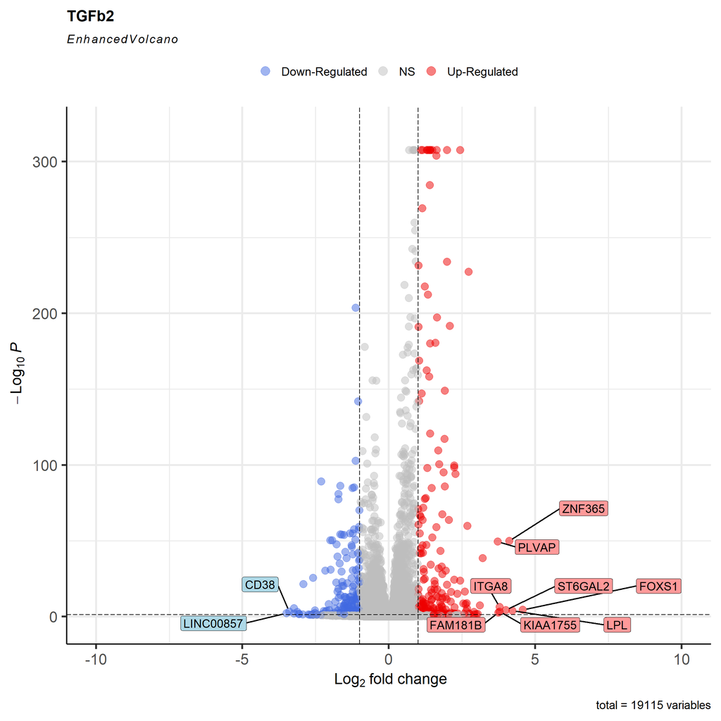

```r
# Add labels for points with positive log2FoldChange

volc3 <- volc2 + geom_label_repel(data = sigdeg_df[sigdeg_df$log2FoldChange > 1 & sigdeg_df$padj <0.05 & sigdeg_df$symbol %in% selected$symbol, ], #labels postive DEGs in 'selected'
                                  aes(x = log2FoldChange, y = -log10(padj), label = symbol),
                                  size = 5,
                                  label.size = 0.1,
                                  box.padding = 1,  # Increase box padding
                                  point.padding = 0.5,  # Increase point padding
                                  segment.color = 'black',
                                  fill = "#FF9999",
                                  segment.size = 0.8,
                                  nudge_x = 1,
                                  max.time = 5, # Nudge labels to the right
                                  max.overlaps = 30)  # Ensure all labels are shown
```

Save and print text to show code has run through (good for if using a function)

```r
ggsave(file =paste0(out_path,cytokine,"_volcano_001.svg"),
       plot=volc3, #plot
       width=13,   #width
       height=15)  #height

print(paste0("Volcano plot generated for ",cytokine,"."))
```

```
## [1] "Volcano plot generated for TGFb2."
```

```r
#}
```

```r
#volcanomaker(cytokine = "TNFa", version = "001")
```

# Functional Analyses

The following sections of code outline packages used and steps undertaken to identify biological themes and pathways enriched by each treatment. This includes:

1. Over Representation Analysis
2. Gene Set Enrichment Analysis
3. Phenotype and pathway of interest filtering

## Over-Representation Analysis

Pathway enrichment was performed in **clusterProfiler**, both by direct referencing to downloaded GMT files as well as integrated referencing through **clusterProfiler**.

### Custom .GMT ORA

First, a pathway was assigned to reference lists folder.

```r
ref_path <- "reference_data/"
```

Next, a background gene list was generated, using all HGNC/NCBI named genes in the raw data file.

```r
library('org.Hs.eg.db')
library('clusterProfiler')

bg <- read.csv(paste0(in_path,"raw_counts.csv"), header = TRUE)
rownames(bg) <- bg$ID
bg <- bg[,c(1,48)]
bg <- bg %>%
  mutate("symbol" = mapIds(org.Hs.eg.db,
                         keys = rownames(bg),
                         keytype = "ENSEMBL",
                         column = "SYMBOL"))%>%
  mutate("ENTREZ" = mapIds(org.Hs.eg.db,
                         keys = rownames(bg),
                         keytype = "ENSEMBL",
                         column = "ENTREZID"))

bg <- na.omit(bg) %>%
  dplyr::select(ID, ENTREZ, symbol)

bgnames <- bg$symbol
```

GMT files were downloaded from www.gsea-msigdb.org, and a loop was used to identify and create an RDS of overlapping genes between GMT and background list for easier reference.

```r
    #subset genes in background from genes in gmt files,
          #these ones are from www.gsea-msigdb.org below uses a loop to identify and then make a new file containing gene subset


     gmt_files <- list.files(path = ref_path, pattern = '.gmt', full.names = TRUE)
    for (i in gmt_files){
      file <- gmt_files[i] #set a variable for position in list
      pwl <- read.gmt(file)
      pwl <- pwf[pwf$gene %in% bgnames,]
      filename <- paste(gsub('c2.cp\\.', '',
                             gsub('.v2023.2.*$', '', file)), '.RDS', sep = '') #assumes you are using 2023.2. files
      saveRDS(pwf, filename)
    }

      #NOTE: only need to do this once, have to manually rename RDS files to source.RDS as I can't figure out how to do it automatically
      #NOTE: genes may have multiple functions in the same GSEA set, therefore pwl may have more genes than your background set
      #NOTE: have to delete RDS files if you want to run it twice.
```

A custom function was written to then read in a chosen RDS, run over-representation analysis for up and down regulated significant DEGs at specified limits for a specified treatment, clean pathway names, and output a .CSV and dot plot of findings.

```
## [1] "reactome selected"
## [1] "Saving reactome clusterprofiler results for TNFa."
```

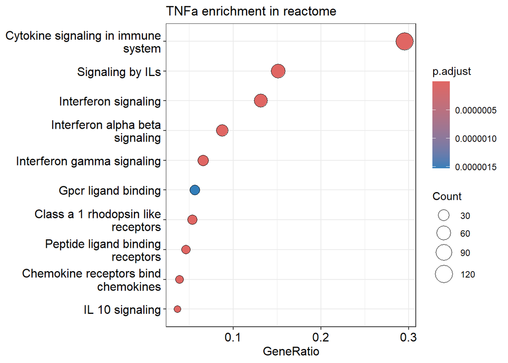

```r
clusteranalysis <- function(cytokine, path_base, padj_cutoff, genecount_cutoff){


   #import dataset
  file_names <- list.files(path = in_path, pattern = cytokine, full.names = TRUE)

  # Loop through the file names
  for (file_name in file_names) {
    # Read the file
    df <- read.csv(file_name)

    # Perform operations on 'df'
  }


  ##Begin code for cluster analysis

  #Select RDS based on top
     if(path_base == 'KEGG'){
       bg_genes <- readRDS(paste0(ref_path, 'kegg_medicus.RDS'))
       print("KEGG selected")
     } else if(path_base == 'reactome'){
       bg_genes <- readRDS(paste0(ref_path, 'reactome.RDS'))
       print("reactome selected")
     }else if(path_base == 'biocarta'){
       bg_genes <- readRDS(paste0(ref_path, 'biocarta.RDS'))
       print("biocarta selected")
     } else if(path_base == 'pid'){
       bg_genes <- readRDS(paste0(ref_path, 'pid.RDS'))
       print("PID selected")
     } else if(path_base == 'wikipathways'){
       bg_genes <- readRDS(paste0(ref_path, 'wikipathways.RDS'))
       print("wikipathways selected")
     } else {
       stop('Invalid background genes.')
     }

    #ensure no non-significant DEGs
  df <- df[df$diffexpressed!= 'NO',]


      #split dataset into 2 lists
  deg_results_list <- split(df, df$diffexpressed)

  deg_down <- deg_results_list$DOWN
  deg_up <- deg_results_list$UP

  #Run clusterprofiler
    #set output path
  name_of_comparison <- paste0(cytokine,"_vs_control")
  filename <- paste0(out_path, 'clusterProfiler/', name_of_comparison, '_', path_base)

    #runs the enrichment analysis for up and down-regulated genes separately

  res <- lapply(names(deg_results_list),
                function(x) enricher(gene = deg_results_list[[x]]$symbol,
                                     TERM2GENE = bg_genes))


      #assigns names from deg_results_list to results

    names(res) <- names(deg_results_list)

    #Convert the list of enrichResults for each sample_pattern to a dataframe with the pathways

  res_df <- lapply(names(res), function(x) rbind(res[[x]]@result))
  names(res_df) <- names(res)
  res_df <- do.call(rbind, res_df)

  head(res_df)

  res_df <- res_df %>% mutate(minuslog10padj = -log10(p.adjust),
                              diffexpressed = gsub('\\.GOBP.*$|\\.KEGG.*$|\\.REACTOME.*$|\\.BIOCARTA.*$', '', rownames(res_df)))

# select only target pathways that meet preset parameters
target_pws <- unique(res_df$ID[res_df$p.adjust < padj_cutoff & res_df$Count > genecount_cutoff])

res_df <- res_df[res_df$ID %in% target_pws,]

#long list of substitutions I found online which neaten the descriptions
res_df$Description <- gsub('(H|h)iv', 'HIV',
                           gsub('pd 1', 'PD-1',
                                gsub('ecm', 'ECM',
                                     gsub('(I|i)nterleukin', 'IL',
                                          gsub('(R|r)na', 'RNA',
                                               gsub('(D|d)na', 'DNA',
                                                    gsub(' i ', ' I ',
                                                         gsub('(A|a)tp ', 'ATP ',
                                                              gsub('(N|n)adh ', 'NADH ',
                                                                   gsub('(N|n)ad ', 'NAD ',
                                                                        gsub('t cell', 'T cell',
                                                                             gsub('b cell', 'B cell',
                                                                                  gsub('built from .*', ' (...)',
                                                                                       gsub('mhc', 'MHC',
                                                                                            gsub('mhc class i', 'MHC I',
                                                                                                 gsub('mhc class ii', 'MHC II',
                                                                                                      stringr::str_to_sentence(
                                                                                                        gsub('_', ' ',
                                                                                                             gsub('BIOCARTA_|PID_|KEGG_MEDICUS_REFERENCE_|REACTOME_', '', res_df$Description)))))))))))))))))))
print(paste0('Saving ', path_base,' clusterprofiler results for ',cytokine,"."))
write.csv(res_df, paste0(filename, '_resclusterp.csv'), row.names = FALSE)

if (nrow(res_df) > 0){

enrichres <- new("enrichResult",
                 readable = FALSE,
                 result = res_df,
                 pvalueCutoff = 0.05,
                 pAdjustMethod = "BH",
                 qvalueCutoff = 0.2,
                 organism = "human",
                 ontology = "UNKNOWN",
                 gene = df$symbol,
                 keytype = "SYMBOL",
                 universe = unique(bg_genes$gene),
                 gene2Symbol = character(0),
                 geneSets = bg_genes)

  dot <-dotplot(
    enrichres,
    x = "GeneRatio",
    title = paste0(cytokine," enrichment in ", path_base),
    orderBy = "x",
    label_format = 30,
    )
print(dot)
  ggsave(file =paste0(out_path,"/",cytokine,"_",path_base,"_enrichment_dotplot.svg"), plot=dot, width=10, height=14)

  } else{
    print(paste0("no pathways were enriched for ",cytokine," in ",bg_genes))
  }
}

cytokines <- c("thrombin", "TGFb2", "TGFb1", "TNFa")  # Replace with your actual cytokines
path_base <- c("KEGG", "reactome", "biocarta", "pid", "wikipathways")

clusteranalysis(cytokine = "TNFa",
                path_base = "reactome",
                padj_cutoff = 0.05,  # p-adjusted threshold, used to filter out pathways
                genecount_cutoff = 5  # minimum number of genes in the pathway, used to filter out pathways
)
```

Although useful in allowing a wide array of pathway databases to be investigated simultaneously, this method does not integrate effectively for visualisation, and was thus only run to assess if a treatment was eligible for ORA enrichment and assess the pathway categories reflected by major databases.

### GOora and GOChord

```r
library('GOplot')
library(enrichplot)

treatment = "TGFb2" #set treatment if not using function

#GO <- function(treatment, version){ #unhash and collate lines till 1045 to use as a function



#set file name (change path to change selection)
  #will look for file names with an _ following, so robust against compound treatments

  file_name <- list.files(path = in_path, pattern = paste0(treatment,"_"), full.names = TRUE)
  df <- read.delim(file_name, header = TRUE, sep = ",")

GOora <- enrichGO(gene = df$symbol,
        'org.Hs.eg.db',
        universe = bg$symbol,
        minGSSize = 10,
        keyType = "SYMBOL",
        pAdjustMethod = "fdr",
        ont = "BP",
        pvalueCutoff = 0.01
        )

GOres <- as.data.frame(GOora@result) # split out results

#write.csv(GOres, file =paste0(out_path,treatment,"_GO_results_padj0.01_",version,".csv"))
```

```
##                    ID                                    Description GeneRatio
## GO:0030198 GO:0030198              extracellular matrix organization    28/285
## GO:0043062 GO:0043062           extracellular structure organization    28/285
## GO:0045229 GO:0045229  external encapsulating structure organization    28/285
## GO:0040013 GO:0040013              negative regulation of locomotion    23/285
## GO:0042476 GO:0042476                                  odontogenesis    13/285
## GO:0060390 GO:0060390 regulation of SMAD protein signal transduction    10/285
##              BgRatio                pvalue           p.adjust
## GO:0030198 327/18353 0.0000000000002467035 0.0000000003300227
## GO:0043062 328/18353 0.0000000000002660397 0.0000000003300227
## GO:0045229 329/18353 0.0000000000002868100 0.0000000003300227
## GO:0040013 403/18353 0.0000000893314117569 0.0000770930083462
## GO:0042476 133/18353 0.0000001574544074197 0.0000919693942550
## GO:0060390  72/18353 0.0000001598541035718 0.0000919693942550
##                        qvalue
## GO:0030198 0.0000000002608461
## GO:0043062 0.0000000002608461
## GO:0045229 0.0000000002608461
## GO:0040013 0.0000609334261247
## GO:0042476 0.0000726915502558
## GO:0060390 0.0000726915502558
##                                                                                                                                                                              geneID
## GO:0030198 VWA1/TNR/TGFB2/ANTXR1/DPP4/FAP/ADAMTS9/PTX3/TGFBI/COL1A2/PRSS2/MATN2/OLFML2A/ENG/MMP1/ITGA8/SPOCK2/MANSC4/POSTN/RGCC/COL4A1/COL4A2/FBLN5/MMP2/MMP28/COL9A3/APLP1/ADAMTS1
## GO:0043062 VWA1/TNR/TGFB2/ANTXR1/DPP4/FAP/ADAMTS9/PTX3/TGFBI/COL1A2/PRSS2/MATN2/OLFML2A/ENG/MMP1/ITGA8/SPOCK2/MANSC4/POSTN/RGCC/COL4A1/COL4A2/FBLN5/MMP2/MMP28/COL9A3/APLP1/ADAMTS1
## GO:0045229 VWA1/TNR/TGFB2/ANTXR1/DPP4/FAP/ADAMTS9/PTX3/TGFBI/COL1A2/PRSS2/MATN2/OLFML2A/ENG/MMP1/ITGA8/SPOCK2/MANSC4/POSTN/RGCC/COL4A1/COL4A2/FBLN5/MMP2/MMP28/COL9A3/APLP1/ADAMTS1
## GO:0040013                                PODN/RHOB/DPP4/IGFBP5/SEMA3G/ADAMTS9/CHRD/MCTP1/SEMA3A/SERPINE1/STC1/CCN3/IL33/ENG/NRG3/RGCC/TPM1/SEMA7A/CX3CL1/MMP28/LDLRAD4/SMAD7/CLDN5
## GO:0042476                                                                                          CD34/TGFB2/SCN5A/SCN10A/EDN1/AQP1/INHBA/COL1A2/SERPINE1/AQP3/TMT1A/TNFSF11/JAG2
## GO:0060390                                                                                                                TGFB2/GDF7/INHBA/GDF6/CCN3/ENG/SMAD6/LDLRAD4/SMAD7/PMEPA1
##            Count
## GO:0030198    28
## GO:0043062    28
## GO:0045229    28
## GO:0040013    23
## GO:0042476    13
## GO:0060390    10
```

The Chord diagram generated in GOplot requires a specific data structure. The following code will transform an enrichGO/KEGG/WP etc. object to a usable format for *GOChord()*

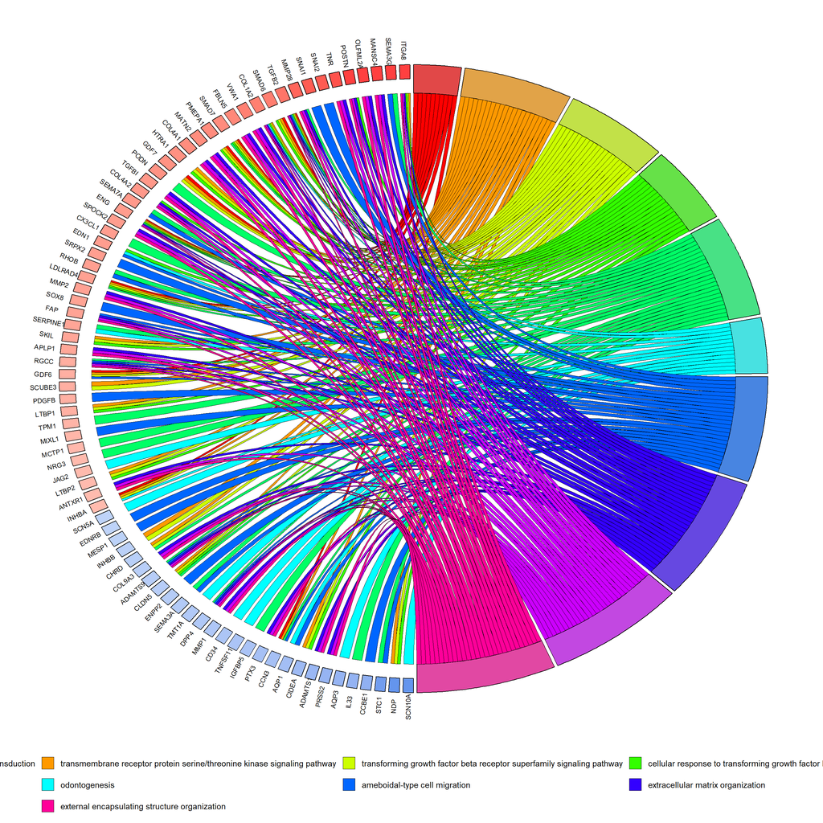

```r
# Chord Diagram -----------------------------------------------------------

  #create an object for Chord data and adjust to fit requirements to use GOChord

    #Circle_dat object

      #Terms

        ChordGO <- GOres%>%
          dplyr::select(ID, Description, geneID, p.adjust)%>%
          dplyr::mutate(new_column = "BP", .before = everything()) #if enrichment was performed in a specific ontology,
                                                                    #a column must be generated for this, even though it isn't read
                                                                    #REMOVE THIS LINE IF USING ONT = 'ALL'

        #rename columns to fit GOChord setup

        rownames(ChordGO) <- NULL
        colnames(ChordGO)[1] <- "Category" #rename ONTOLOGY column to fit GOChord setup
        colnames(ChordGO)[2] <- "ID"
        colnames(ChordGO)[3] <- "Term"
        colnames(ChordGO)[4] <- "Genes"
        colnames(ChordGO)[5] <- "adj_pval"

        #change gene strings to be comma seperated factors (GOChord requirement)

        ChordGO$Genes <- str_replace_all(ChordGO$Genes, "/", ", ")

        ChordGO$Genes <- as.factor(ChordGO$Genes)

      #Genes

        #rename columns to fit GOChord setup

        genelist <- df%>%
          dplyr::select(symbol, log2FoldChange, baseMean, stat, pvalue, padj)
        colnames(genelist)[1] <- "ID"
        colnames(genelist)[2] <- "logFC"
        colnames(genelist)[3] <- "AveExpr"
        colnames(genelist)[4] <- "t"
        colnames(genelist)[5] <- "P.Value"
        colnames(genelist)[6] <- "adj.P.Val"

    #circle_dat object for GOChord

    circ <- circle_dat(ChordGO, genelist)

  #Log Fold Change object

    LFC <-data.frame(ID = df$symbol, LogFC = df$log2FoldChange)

  #Processes object

    set.seed(12345)
    pairwise <- pairwise_termsim(GOora, showCategory = 10) #performs pairwise comparison of gene names in top 10 GO categories
    termsim <- pairwise@termsim #create object of term simulation results
    set.seed(12345)
    km <- kmeans(termsim, centers = 3) # run K-means clustering on the termsim matrix, generally use K = sqrt(N)
    km_res <- as.data.frame(km$cluster)
    km_res <- km_res%>%
      rename("cluster" = "km$cluster")%>%
      rownames_to_column(var ="Description")%>%
      arrange(cluster)

  processes <- c(head(km_res$Description, 10)) #export a list of the 10 categories, now arranged into K means clusters

chord <- chord_dat(circ, LFC, processes)

GChor <- GOChord(chord, space = 0.01,
                 gene.order = 'logFC',
                 gene.space = 0.15,
                 gene.size = 3,
                 border.size = 0,
                 lfc.min = -2.5,
                 lfc.max = 2.5)

print(GChor)
```

```r
ggsave(file =paste0(out_path,treatment,"_GOChord_",version,".svg"), plot=GChor, width=22, height=20)

print(paste0("Chord 1 Generated for ", treatment,"."))
```

```
## [1] "Chord 1 Generated for TGFb2."
```

### Clustered Process Map

Although not shown in my thesis, a clustered process map is a great way to visualise the K means clustering performed

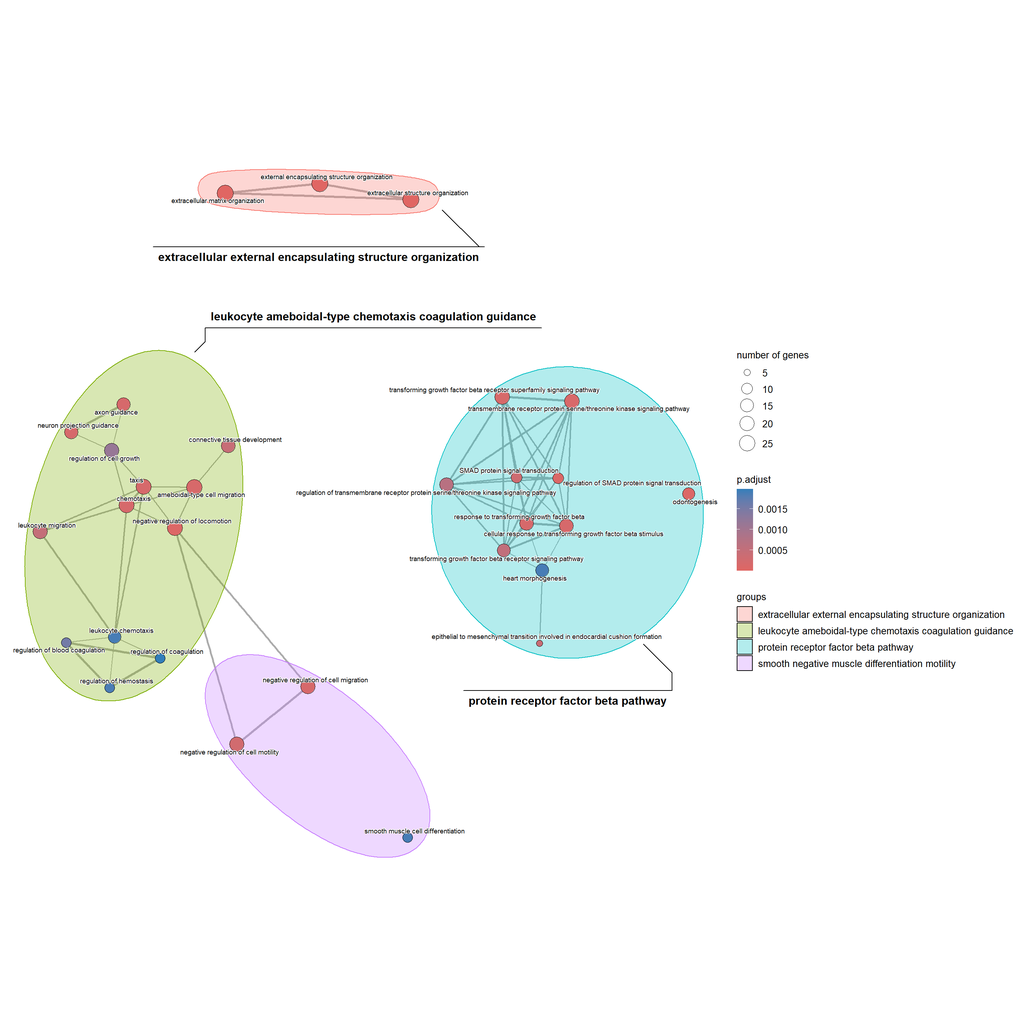

```r
# Clustered processes map -------------------------------------------------

set.seed(12345)
pairwise <- pairwise_termsim(GOora, showCategory = 30)
termsim <- pairwise@termsim

set.seed(12345)
eplot <- emapplot(pairwise,
                  showCategory = 30,
                  node_label = 'all',
                  cluster.params = list(cluster = TRUE, #cluster logic
                                        legend = TRUE, #legend logic
                                        label_words_n = 5, #number of words in label generation
                                        method = stats::kmeans, #clustering method
                                        n=4, #number of clusters (default is sqrt(nodes))
                                        label_style = "ggforce" #options are shadowtext or ggforce
                  ),
                  edge.params = list(show = TRUE, #show connections logic
                                     min = 0.2), #minimum connection strength
                  layout.params = list(layout = 'kk' #layout style
                  ),
                  cex.params = list(category_node = 1, #node scale
                                    category_label = 0.5, #node label size
                                    line = 0.5,
                                    label_group = 1.5),
                  highlight.params = list(),
                  force = 2
)

print(eplot)
```

```r
ggsave(file =paste0(out_path,treatment,"_GOTerm_network_",version,".svg"), plot=eplot, width= 20, height=15)

print(paste0("eplot 1 Generated for ", treatment,"."))
```

```
## [1] "eplot 1 Generated for TGFb2."
```

```r
#}

#GO(treatment = "TNFa",
   #version = "003")
```

## Gene Set Enrichment Analysis

### Individual GSEA

GSEA code below runs all treatments in parallel, generating a list of GSEA objects.

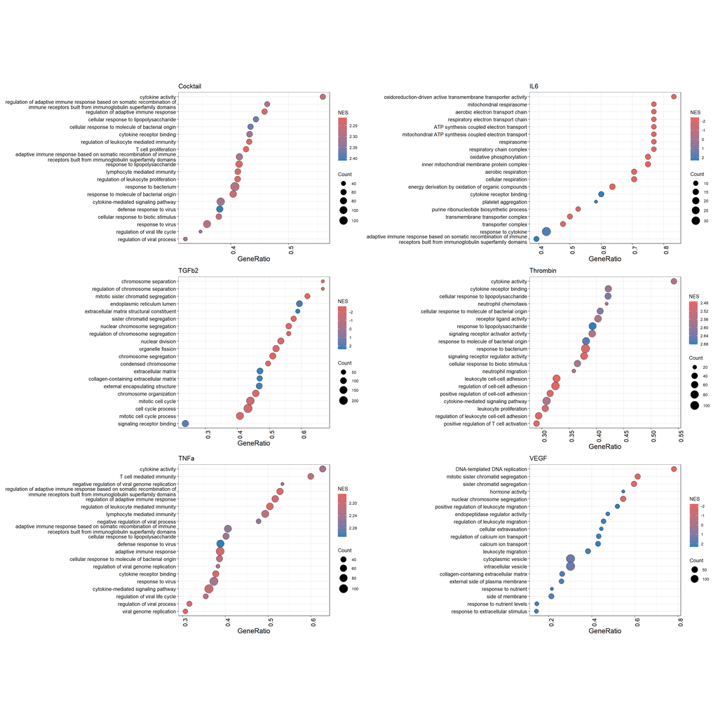

```r
in_path <- "significant_data/"

file_names <- list.files(path = paste0(in_path), pattern = "deg_table_0L2FC_cutoff", full.names = TRUE) #list all files for comparison

gr<- lapply(file_names, function(file) {
  data <- read.csv(file) #read in groups as a list
})
names(gr) <- c("Cocktail", "IL6", "TGFb1", "TGFb2", "Thrombin", "TNFa", "VEGF")

gr <-  lapply(gr, function(df) { #must be labelled with with entrezID to allow for comparison
  df %>%
    mutate(ENTREZID = mapIds(org.Hs.eg.db,
                             keys = df$X,
                             keytype = "ENSEMBL",
                             column = "ENTREZID")) %>%
    filter(!is.na(ENTREZID))
})

##Order for GSEA

genes <- lapply(gr, function(df) {
  df <- df %>%
    arrange(desc(log2FoldChange))
  named_vector <- setNames(df$log2FoldChange, df$ENTREZID)
  named_vector <- na.omit(named_vector)
  return(named_vector)
})

names(genes) <- names(gr)

# GO GSEA -----------------------------------------------------------------

gsea <- lapply(genes,function(vec){
  data <- gseGO(geneList = vec,
                OrgDb = org.Hs.eg.db,
                ont = "ALL",
                pvalueCutoff = 0.05,
                minGSSize = 10
  )
  return(data)
})

names(gsea) <- names(genes)

dotpl <- lapply(names(gsea), function(df){
  data <- gsea[[df]]

  if (nrow(data) == 0) {
    message(paste("Data frame", df, "is empty and will be skipped."))
    return(NULL)  # Return NULL for empty dataframes
  }else{

    dot <- dotplot(data,
                   color = "NES",
                   x = "geneRatio",
                   showCategory = 20,
                   font.size = 24,
                   label_format = 75,
                   title = df)+

      #coord_flip()+ #uncomment to flip to portrait

      #facet_grid(~.sign,) + #uncomment to seperate activated and repressed

      theme(panel.spacing = unit(0.1, "cm",data = NULL),
            aspect.ratio = 1/1,
            axis.text.x = element_text(size = 12, angle = 90, vjust = 1, hjust = 1),  # Rotate y-axis labels
            axis.title.x = element_text(size = 14),
            axis.text.y = element_text(size = 10),
            axis.title.y.left = element_text(vjust = 3),
            legend.text = element_text(size = 8),  # Adjust legend text size
            legend.title = element_text(size = 10),
            geom_dotplot(binwidth = 10, dotsize = 1),
      )

    return(dot)
  }
})
```

This same workflow can also be applied in KEGG and WikiPathways, however it is important to note the clusterProfiler functions require slightly different inputs.

If this is desired, the below code segments could be inserted to replace GO GSEA.

```r
# KEGG GSEA ---------------------------------------------------------------

gsek <- lapply(genes,function(vec){
  data <- gseKEGG(geneList = vec,
                  organism = "hsa",
                  pvalueCutoff = 0.05,
                  minGSSize = 10
  )
  return(data)
})

lapply(names(gsek), function(df){
  data <- gsek[[df]]@result
  write.csv(data, file = paste0(out_path,df,"_GSEKEGG_001.csv"))
})

# WP GSEA -----------------------------------------------------------------

gsew <- lapply(genes,function(vec){
  data <- gseWP(geneList = vec,
                organism = "Homo sapiens",
                pvalueCutoff = 0.05,
                minGSSize = 10
  )
  return(data)
})

lapply(names(gsew), function(df){
  data <- gsew[[df]]@result
  write.csv(data, file = paste0(out_path,df,"_GSEWP_001.csv"))
})


names(gsea) <- names(gr)


lapply(names(gsea), function(df){
  data <- gsea[[df]]@result
  write.csv(data, file = paste0(out_path,df,"_GSEKEGG_001.csv"))
})
```

### Comparative GSEA

*comparecluster* combines a pairwise analysis with GSEA, to characterise the overlapping and diverging pathways between multiple treatment groups.

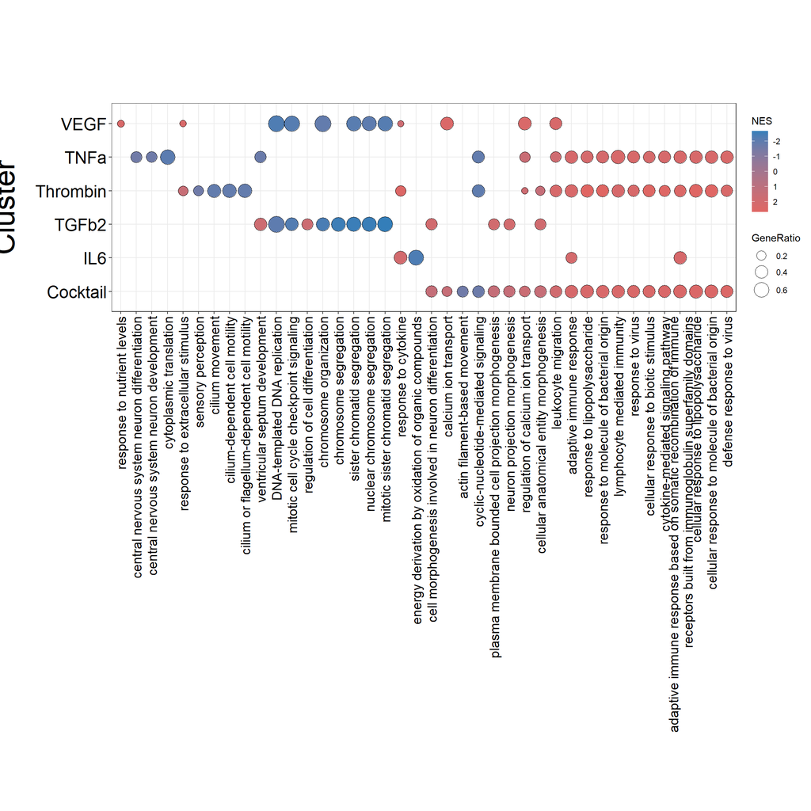

```r
#comparative GSEA

ck <- compareCluster(geneCluster = genes, #compare gene names in lists
                     fun = gseGO,
                     OrgDb = org.Hs.eg.db,
                     ont = "BP",
                     pvalueCutoff = 0.05,
                     minGSSize = 20,
)


options(enrichplot.colours = c("#347EB9","#e06663"))
dot <- dotplot(ck,
               color = "NES",
               showCategory = 5,
               font.size = 32,
               split = ".sign",
               label_format = 75,
)+

  coord_flip()+ #remove to return to portrait

  #facet_grid(~.sign,) + #remove this line to homogenise activated and repressed

  theme(panel.spacing = unit(0.1, "cm",data = NULL),
        aspect.ratio = 1/3,
        axis.text.x = element_text(size = 14, angle = 90, vjust = 0.5, hjust = 1),  # Rotate y-axis labels
        axis.text.y = element_text(size = 18),
        axis.title.y.left = element_text(vjust = 3),
        geom_dotplot(binwidth = 50, dotsize = 1.5)
  )

dot
```

## Phenotype filtering

Phenotype filtering was performed by intersecting DEG lists with filter lists, this same technique was applied for any specified filters, including ETC genes.

```r
library(pheatmap)

cytokines <- c("ALL","TNFa","Thrombin","TGFb2") #set treatments
Phenotypes <- c("inflamm","fibro","angio") #set phenotypes

red2blue <- colorRampPalette(c("#2066b4", "#ffffff", "#b4182a"))(100) #set colour scale

pheno_list <- list() #open an empty list outside of for loop

for (phenotype in Phenotypes){

  for (cytokine in cytokines) {

    res_means <-read.delim(paste0("significant_data/",cytokine,"_deg_table_1L2FC_nobaseMean_cutoff_004.csv"),
                           header = TRUE, row.names = 1, sep = ",")%>%
      mutate_all(~replace(., .=="", "no")) # read in DEGs and remove blanks

    potential_targets <- read.delim(paste0("reference_data/",phenotype,"_Genecard_5.0relevance.csv"), header = TRUE, sep = ",") %>%
      as.data.frame() #read in filter list

    pheno_list[[cytokine]] <- merge(res_means, potential_targets, by.x = "symbol", by.y = "Gene.Symbol") #transect DEG and filter list

    print(paste0(cytokine," ", phenotype," filtered list generated")) #print message to show it worked

    #write.csv(pheno_list[[cytokine]], file = paste0(out_path,cytokine,"_",phenotype,"_filtered_genes_1L2FC.csv")) # write out a csv

    }

    heat <- lapply(pheno_list, function(cyto) {
      row.names(cyto) <- cyto$symbol #pheatmap must have gene names in rownames
      cyto$log2FoldChange <- as.numeric(cyto$log2FoldChange) #select only l2FC values
      cyto %>%
        dplyr::select(log2FoldChange) %>% #select only symbols
        na.omit()

    })

    names(heat) <- names(pheno_list) #carry over names

    heatmaps <- lapply(names(heat), function(cyto) {
      p <- pheatmap(heat[[cyto]],
                    kmeans_k = NA,
                    breaks = seq(-3, 3, length.out = 101),
                    scale = "none",
                    cluster_rows = TRUE,
                    cluster_cols = FALSE,
                    clustering_distance_rows = "maximum",  # Corrected parameter name
                    clustering_method = "complete",
                    color = red2blue,
                    show_colnames = FALSE,
                    fontsize = 14)

      #ggsave(filename = paste0(out_path, cyto, "_", phenotype, "_DEGs_001.svg"), plot = p[[4]], width = 15, height = (nrow(heat[[cyto]]) * 0.5), units = "cm")
    })


    names(heatmaps) <- names(heat)

    pheno_overlap <- Reduce(function(x, y) merge(x, y, by = "symbol", all = TRUE), pheno_list)
    pheno_overlap <- pheno_overlap %>% # as the reduce function generates replicate names,
      setNames(make.unique(names(.)))  # we have to manually change them to be unique

    heat_overlap <- pheno_overlap %>%
      dplyr::select(3,18,33,48)  %>%
      rename_with(~ c("ALL","TNFa", "Thrombin", "TGFb2")) %>%
      mutate_all(~replace(., is.na(.), 0)) %>%
      mutate(across(everything(), as.numeric)) %>%
      as.matrix

    rownames(heat_overlap) <-pheno_overlap$symbol

    p_over <- pheatmap(heat_overlap,
                       kmeans_k = NA,
                       breaks = seq(-3, 3, length.out = 101),
                       scale = "none",
                       cluster_rows = TRUE,
                       cluster_cols = FALSE,
                       clustering_distance_rows = "euclidean",  # Corrected parameter name
                       clustering_method = "median",
                       color = red2blue,
                       show_colnames = TRUE,
                       fontsize = 14)

    #ggsave(filename = paste0(out_path, phenotype,"_overlapped_DEGs_001.svg"), plot = p_over[[4]], width = 15, height = (3 + (nrow(heat[[cyto]]) * 0.5)), units = "cm")
    #write.csv(pheno_overlap, file = paste0(out_path,cytokine,"_",phenotype,"_filtered_genes_1L2FC.csv"))
  }
```

[figure not shown]

Similarly, phenotype filtering can also be applied to a volcano plot, as shown here:

```r
cytokine = "ALL"
version = "001"

#volcanomaker <- function(cytokine,version){
  set.seed(12345)

  res <- results(dds, contrast = c("condition", cytokine, "Control"))
  sigdeg <- na.omit(res)

  sigdeg_df<- as.data.frame(sigdeg)

#Labelling system
  sigdeg_df$symbol<- mapIds(org.Hs.eg.db,
                            keys = rownames(sigdeg_df),
                            keytype = "ENSEMBL",
                            column = "SYMBOL")

  sigdeg_df <- sigdeg_df %>%
    mutate(diffexpressed = case_when(
      log2FoldChange > 1 & padj < 0.05 ~ "UP",
      log2FoldChange < -1 & padj < 0.05 ~ "DOWN",
      between(sigdeg_df$log2FoldChange, -1, 1) ~ "NO",
      padj > 0.05 ~ 'NO',
  ))

  sigdeg_df$padj <- ifelse(sigdeg_df$padj == 0, .Machine$double.xmin, sigdeg_df$padj) #ifelse to replace 0 values in padj with machine minimum


filtered_sigdeg_df1 <- sigdeg_df %>%
    dplyr::filter(diffexpressed != "NO") %>%
    dplyr::filter(!is.na(symbol))

  fibr_pt <- read.csv(paste0(ref_path,"fibro_Genecard_5.0relevance.csv"), header= FALSE)

  fibr_selected <- filtered_sigdeg_df1[filtered_sigdeg_df1$symbol %in% fibr_pt$V1,]

  inf_pt <- read.csv(paste0(ref_path,"inflamm_Genecard_5.0relevance.csv"), header= FALSE)

  inf_selected <- filtered_sigdeg_df1[filtered_sigdeg_df1$symbol %in% inf_pt$V1,]

  angio_pt <- read.csv(paste0(ref_path,"angio_Genecard_5.0relevance.csv"), header= FALSE)

  angio_selected <- filtered_sigdeg_df1[filtered_sigdeg_df1$symbol %in% angio_pt$V1,]

  fxi <- fibr_selected[fibr_selected$symbol %in% inf_selected$symbol,]
  fxa <- fibr_selected[fibr_selected$symbol %in% angio_selected$symbol,]
  ixa <- inf_selected[inf_selected$symbol %in% angio_selected$symbol,]
  ixaxf <- fibr_selected[fibr_selected$symbol %in% ixa$symbol,]

  pheno_sigdeg_df1 <- filtered_sigdeg_df1 %>% #creates a column in data frame which reflects which phenotypes the
    mutate(phenotype = case_when(
      symbol%in% ixaxf$symbol ~ 'fully pleitropic',
      symbol%in% ixa$symbol ~ 'inflam and fibro',
      symbol%in%fxa$symbol ~ 'fibro and angio',
      symbol%in%fxi$symbol ~ 'fibro and inflam',
      symbol%in%fibr_selected$symbol ~ 'fibro',
      symbol%in%inf_selected$symbol ~ 'inflam',
      symbol%in%angio_selected$symbol ~ 'angio',
      TRUE ~ 'NO'
    ))


  keyvals <- ifelse(sigdeg_df$symbol %in% ixaxf$symbol,"#796261", #all 3
                    ifelse(sigdeg_df$symbol %in% fxi$symbol,"#ff26fa" , #fibrosis and inflammation only
                           ifelse(sigdeg_df$symbol %in% fxa$symbol,"#f4ff58", #fibrosis and angiogenesis only
                                  ifelse(sigdeg_df$symbol %in% ixa$symbol,"#63ff6f", #inflammation and angiogenesis only
                                         ifelse(sigdeg_df$symbol %in% fibr_selected$symbol, 'purple3', #fibrosis only
                                                ifelse(sigdeg_df$symbol %in% inf_selected$symbol,"#ff9757", #inflammation only
                                                       ifelse(sigdeg_df$symbol %in% angio_selected$symbol, "#3affa6", #angiogenesis only
                                                              ifelse(sigdeg_df$diffexpressed == "DOWN", 'royalblue',
                                                                     ifelse(sigdeg_df$diffexpressed == "UP", 'red2','grey')))))))))
  names(keyvals)[keyvals == 'purple3'] <- 'Fibrosis Associated'
  names(keyvals)[keyvals == 'royalblue'] <- 'Down-Regulated'
  names(keyvals)[keyvals == 'red2'] <- 'Up-Regulated'
  names(keyvals)[keyvals == "#ff9757"] <- 'inflammation Associated'
  names(keyvals)[keyvals == "#3affa6"] <- 'Angiogenesis Associated'
  names(keyvals)[keyvals == "#ff26fa"] <- 'Fibrosis + Angiogenesis Associated'
  names(keyvals)[keyvals == "#f4ff58"] <- 'Fibrosis + inflammation Associated'
  names(keyvals)[keyvals == "#63ff6f"] <- 'inflammation + Angiogenesis Associated'
  names(keyvals)[keyvals == "#796261"] <- 'All 3'
  names(keyvals)[keyvals == "grey"] <- 'NS'
  # Plot variables ----------------------------------------------------------
unique(keyvals)
```

```
##  [1] "grey"      "red2"      "royalblue" "#ff26fa"   "purple3"   "#63ff6f"
##  [7] "#ff9757"   "#796261"   "#3affa6"   "#f4ff58"
```

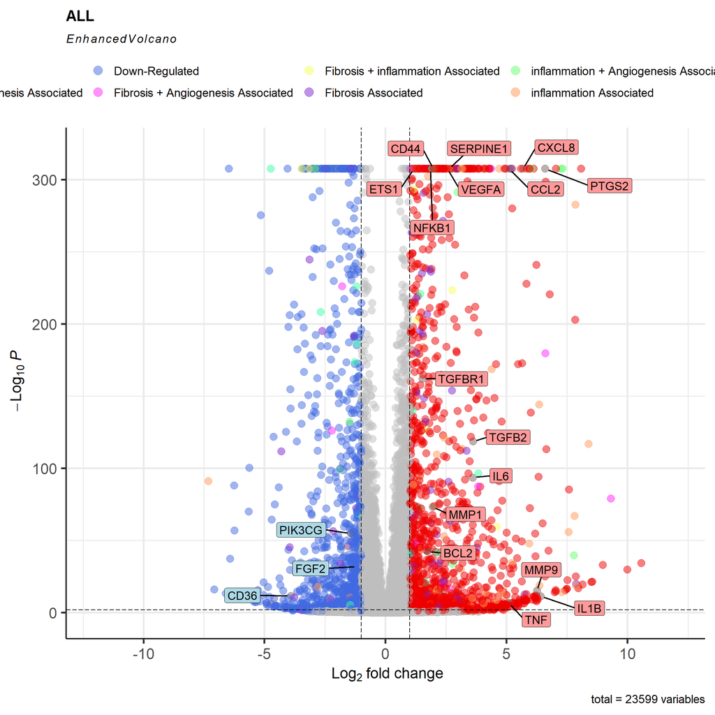

```r
  volc <- EnhancedVolcano(sigdeg_df,
                          x = "log2FoldChange",
                          y = "padj",
                          lab = NA,  # Remove labels for now
                          title = cytokine,
                          colCustom = keyvals,
                          pCutoff = 0.01,
                          FCcutoff = 1,
                          ylim = c(-2, 320),
                          xlim = c(-12, 12),  # Widen x-axis limits
                          pointSize = 4.0,
                          parseLabels = TRUE,
                          max.overlaps = 25)  # Allow more overlaps
  # Add labels using geom_text_repel
  volc2 <- volc + geom_label_repel(data = sigdeg_df[sigdeg_df$log2FoldChange < 0 & sigdeg_df$symbol %in% ixaxf$symbol, ],
                                 aes(x = log2FoldChange, y = -log10(padj), label = symbol),
                                 size = 5,
                                 label.size = 0.1,
                                 box.padding = 1.0,  # Increase box padding
                                 point.padding = 0.5,  # Increase point padding
                                 segment.color = 'black',
                                 segment.size = 0.8,
                                 nudge_x = -2,
                                 max.time = 5,
                                 fill = "lightblue",
                                 nudge_y = 0.5,# Nudge labels to the left
                                 max.overlaps = 20)  # Ensure all labels are shown

  # Add labels for points with positive log2FoldChange
  volc3 <- volc2 + geom_label_repel(data = sigdeg_df[sigdeg_df$log2FoldChange > 0 & sigdeg_df$symbol %in% ixaxf$symbol, ],
                                 aes(x = log2FoldChange, y = -log10(padj), label = symbol),
                                 size = 5,
                                 label.size = 0.1,
                                 box.padding = 1,  # Increase box padding
                                 point.padding = 0.5,  # Increase point padding
                                 segment.color = 'black',
                                 fill = "#FF9999",
                                 segment.size = 0.8,
                                 nudge_x = 1,
                                 max.time = 5, # Nudge labels to the right
                                 max.overlaps = 20)  # Ensure all labels are shown

  volc3
```